# R Notebook

Packages

```r
library(XML)
library(ggplot2)
library(magrittr)
library(yaml)
library(lubridate)
library(RCurl)
library(readxl)
library(BSDA)
library(forecast)
library(caret)
library(RSQLite)
library(psych)
library(RSQLite)
```

Connecting to database

```r
db <- dbConnect(SQLite(), "/Users/theocarr/ClimateChange.db") # Connecting to SQLite
summary(db) # checking the connection
```

```
          Length            Class             Mode
               1 SQLiteConnection               S4
```

Querying data

Global Temperature predictors

```r
query <- "SELECT * FROM GlobalTempPredictors;"
data <- dbSendQuery(db, query) # sending the query
global.temp.predictors <- dbFetch(data) # fetching the output
```

Location Data

```r
query <- "SELECT * FROM GeoData;" # SQL command
data <- dbSendQuery(db, query) # sending the query
```

```
Closing open result set, pending rows
```

```r
geoData <- dbFetch(data) # fetching the output
```

Disconnecting from data base

```r
dbDisconnect(db)
```

```
There are 1 result in use. The connection will be released when they are closed
```

————————————— Global Temperature Prediction —————————— Training and validation data subsets. Training data will be equal to 70% of overall data set

```r
sample.indices <- sample(nrow(global.temp.predictors), size = 0.7*nrow(global.temp.predictors))
training.data <- global.temp.predictors[sample.indices,]
validation.data <- global.temp.predictors[-sample.indices,]
```

Stage 1 model: predict global temperature based on Atmosphere data

```r
stage1 <- lm(data = training.data, GlobalAvg ~ CO2spl+ CH4_GrRt + N2O_GrRt)
summary(stage1)
```

```
Call:
lm(formula = GlobalAvg ~ CO2spl + CH4_GrRt + N2O_GrRt, data = training.data)

Residuals:
     Min       1Q   Median       3Q      Max
-0.56062 -0.19365  0.05099  0.17233  0.55520

Coefficients:
             Estimate Std. Error t value Pr(>|t|)
(Intercept)  9.140211   0.500633  18.257  < 2e-16 ***
CO2spl       0.016896   0.001670  10.116  4.4e-16 ***
CH4_GrRt    -0.004811   0.006421  -0.749   0.4558
N2O_GrRt    -0.186771   0.105456  -1.771   0.0803 .
---
Signif. codes:  0 ‘***’ 0.001 ‘**’ 0.01 ‘*’ 0.05 ‘.’ 0.1 ‘ ’ 1

Residual standard error: 0.2558 on 82 degrees of freedom
Multiple R-squared:  0.6445,    Adjusted R-squared:  0.6315
F-statistic: 49.55 on 3 and 82 DF,  p-value: < 2.2e-16
```

Removing CH4_GrRt from the model:

```r
stage1 <- lm(data = training.data, global.avg2 ~ CO2spl + N2O_GrRt)
summary(stage1)
```

```
Call:
lm(formula = global.avg2 ~ CO2spl + N2O_GrRt, data = training.data)

Residuals:
     Min       1Q   Median       3Q      Max
-0.50652 -0.15175  0.02275  0.17410  0.48919

Coefficients:
             Estimate Std. Error t value Pr(>|t|)
(Intercept) 10.016197   0.418835  23.914  < 2e-16 ***
CO2spl       0.014014   0.001378  10.169 3.04e-16 ***
N2O_GrRt    -0.099711   0.095559  -1.043      0.3
---
Signif. codes:  0 ‘***’ 0.001 ‘**’ 0.01 ‘*’ 0.05 ‘.’ 0.1 ‘ ’ 1

Residual standard error: 0.2326 on 83 degrees of freedom
Multiple R-squared:  0.619, Adjusted R-squared:  0.6098
F-statistic: 67.41 on 2 and 83 DF,  p-value: < 2.2e-16
```

Removing N2O_GrRt from the model:

```r
summary(stage1)
```

[output not shown]

Evaluating the model:

```r
preds <- predict(stage1, validation.data) # model's predictions
actuals <- validation.data$GlobalAvg # actuals values
MSE <- mean((preds-actuals)^2); MSE # calculating mean squared error
```

```
[1] 0.05330968
```

```r
MAD <- mean(abs(preds-actuals)); MAD # calculating mean absolute deviation
```

```
[1] 0.1937285
```

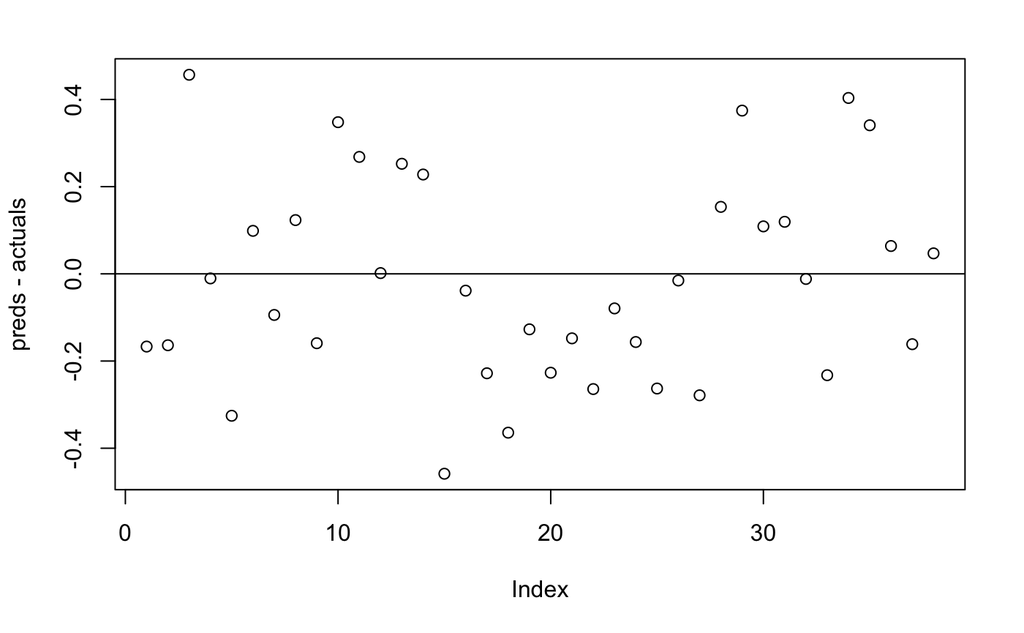

```r
plot(preds-actuals) # Plotting residuals to look for bias
abline(h = 0) # representing residual of 0, for reference
```

The model does not appear to display a noticeable positive or negative bias, and this neutrality is consistent over time (i.e. the model doesn’t more or less biased over time). It is important to note the small size of the validation subset (38 rows). While the model appears to be fairly effective, a larger sample size would help to confirm our findings.

Prediction interval: Given that the CO2 concentration is 400 ppm, what is the expected average global temperature?

```r
CO2spl <- 400
df <- data.frame(CO2spl)
stage1.pred <- predict(stage1, df, interval = "predict"); stage1.pred
```

```
       fit      lwr      upr
1 15.61684 15.06175 16.17192
```

——————————– STAGE 2 ————————————— Training/Validation data subsets

```r
sample.indices <- sample(nrow(geoData), size = 0.7*nrow(geoData))
training.data <- geoData[sample.indices,]
validation.data <- geoData[-sample.indices,]
```

Predicting the difference from the global temperature average based on geographic location

```r
stage2 <- lm(data = training.data, tempDiffs ~ EqDist + PmDist) # creating a linear model
summary(stage2)
```

```
Call:
lm(formula = tempDiffs ~ EqDist + PmDist, data = training.data)

Residuals:
     Min       1Q   Median       3Q      Max
-15.0507  -2.0164   0.5355   2.4438   8.2234

Coefficients:
             Estimate Std. Error t value Pr(>|t|)
(Intercept) 23.439974   0.326976  71.687  < 2e-16 ***
EqDist      -0.607478   0.007693 -78.964  < 2e-16 ***
PmDist      -0.005085   0.001793  -2.836  0.00465 **
---
Signif. codes:  0 ‘***’ 0.001 ‘**’ 0.01 ‘*’ 0.05 ‘.’ 0.1 ‘ ’ 1

Residual standard error: 3.183 on 1037 degrees of freedom
Multiple R-squared:  0.8636,    Adjusted R-squared:  0.8633
F-statistic:  3282 on 2 and 1037 DF,  p-value: < 2.2e-16
```

```r
stage2 <- lm(data = training.data, tempDiffs ~ EqDist) # creating a linear model
summary(stage2)
```

```
Call:
lm(formula = tempDiffs ~ EqDist, data = training.data)

Residuals:
     Min       1Q   Median       3Q      Max
-15.4145  -1.8532   0.5319   2.3963   8.3477

Coefficients:
             Estimate Std. Error t value Pr(>|t|)
(Intercept) 23.074336   0.301508   76.53   <2e-16 ***
EqDist      -0.601856   0.007459  -80.69   <2e-16 ***
---
Signif. codes:  0 ‘***’ 0.001 ‘**’ 0.01 ‘*’ 0.05 ‘.’ 0.1 ‘ ’ 1

Residual standard error: 3.194 on 1038 degrees of freedom
Multiple R-squared:  0.8625,    Adjusted R-squared:  0.8624
F-statistic:  6511 on 1 and 1038 DF,  p-value: < 2.2e-16
```

Plotting best fit line for model

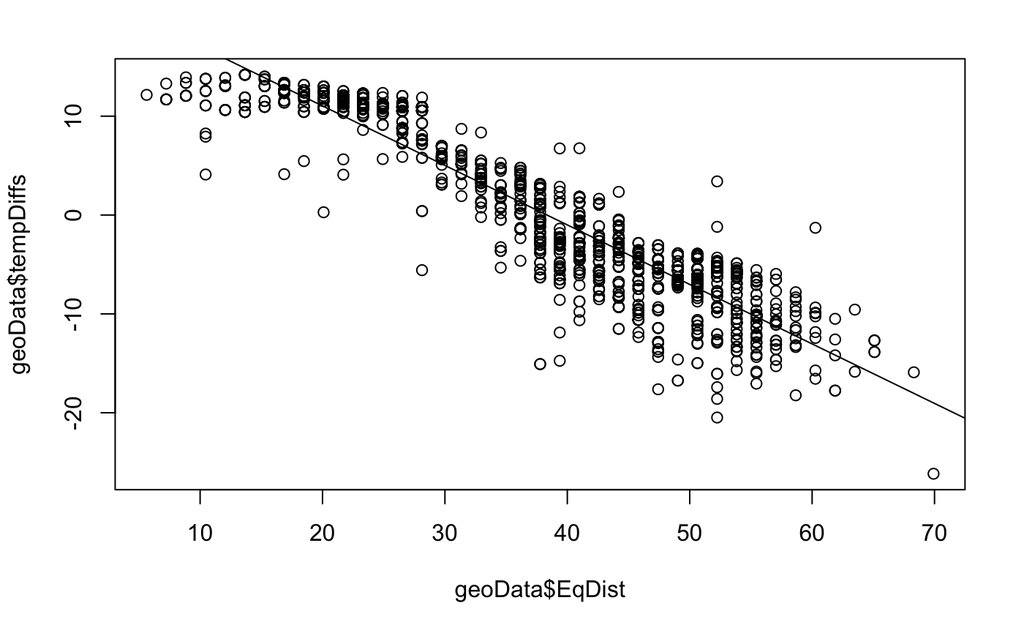

```r
plot(geoData$EqDist, geoData$tempDiffs)
abline(stage2)
```

Model Evaluation (Stage 2)

```r
preds <- predict(stage2, validation.data) # model's predictions
actuals <- validation.data$tempDiffs # actuals values
MSE <- mean((preds-actuals)^2); MSE # calculating mean squared error
```

```
[1] 10.39122
```

```r
MAD <- mean(abs(preds-actuals)); MAD # calculating mean absolute deviation
```

```
[1] 2.502077
```

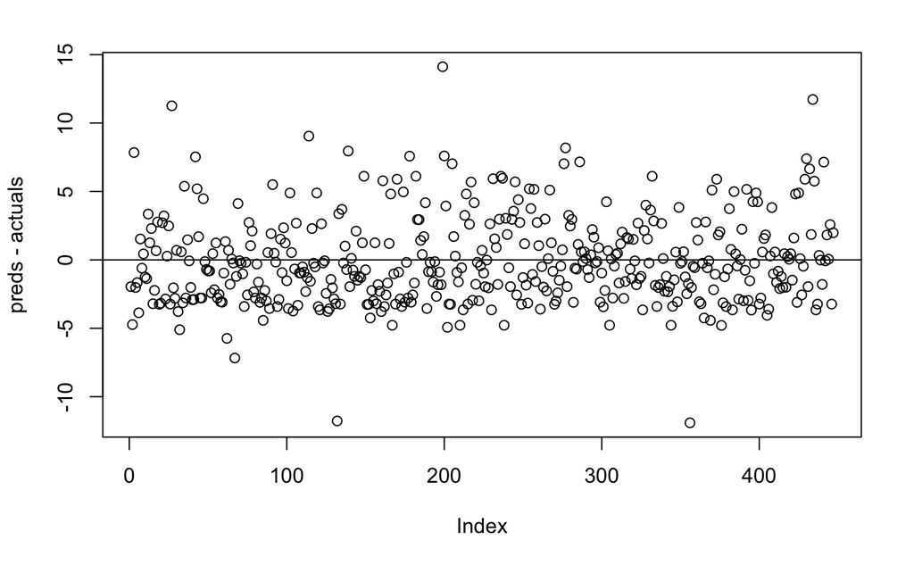

```r
plot(preds-actuals) # Plotting residuals to look for bias
abline(h = 0) # representing residual of 0, for reference
```

K-Means clustering of geography and temperature. First, normalizing the data:

```r
geoData.normal <- data.frame(apply(geoData, 2, zScore))
```

We’ll cluster solely based on temperature difference from global average, and visualize the results by plotting by location.

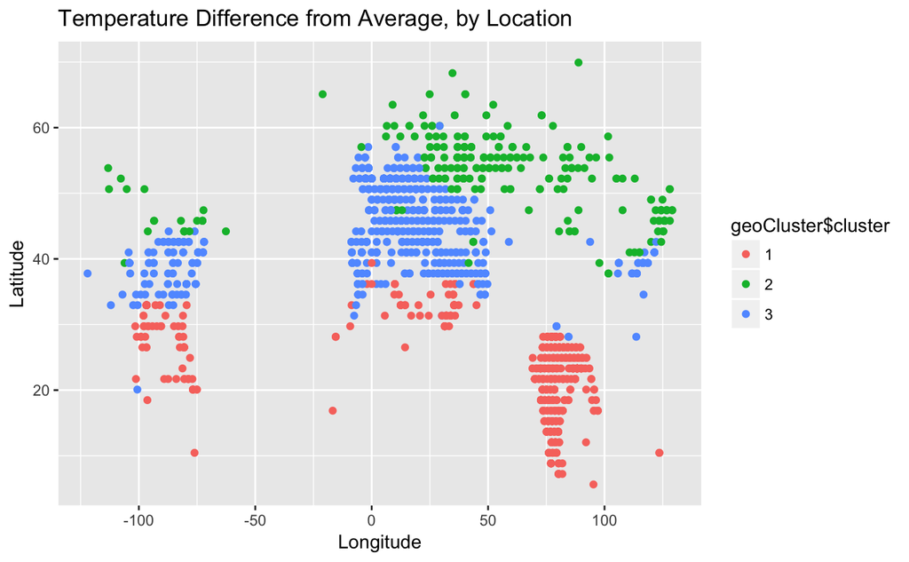

```r
n <- 3 # number of clusters to create
set.seed(20) # setting seed to ensure reproducibility
geoCluster <- kmeans(geoData[, c("tempDiffs")], n, nstart = 20) # creating 3 clusters
# The clusters are based on temperature difference from the global average
geoCluster$cluster <- as.factor(geoCluster$cluster) # Factoring cluster results (one of three)
# Now, plotting Temperature distance by location
ggplot(geoData, aes(PmDist, EqDist, color = geoCluster$cluster)) + geom_point() +
    labs(x = "Longitude", y = "Latitude", title = "Temperature Difference from Average, by Location")
```

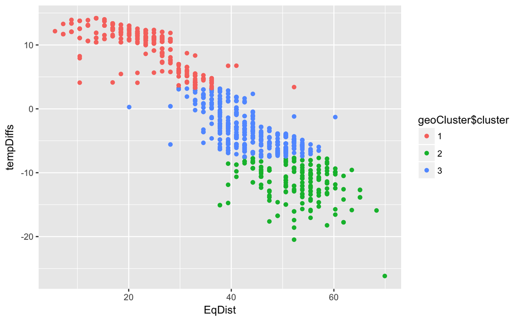

```r
# Visualizing relationship between latitude and cluster
ggplot(geoData, aes(EqDist, tempDiffs, color = geoCluster$cluster)) + geom_point()
```

From the resulting graph, we can see that latitude has a clear effect on the temperature of a location. Longtitude also has a visible effect when taken with latitude. This makes sense - for atmospheric reasons (such as wind and ocean currents), certain regions of the globe have temperatures that are higher or lower than expected based solely on their latitude.

Next, we’ll clustering based on temperature difference AND geographic location.

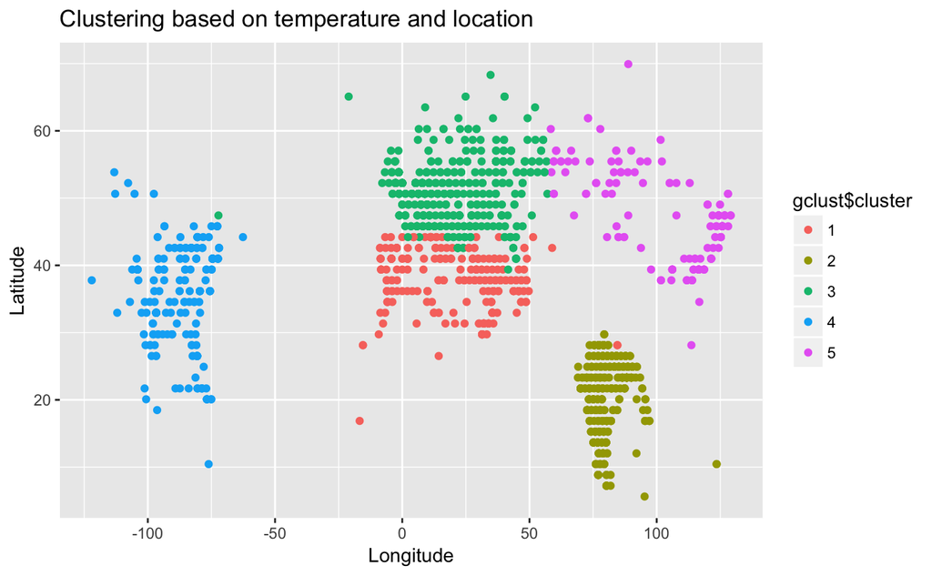

```r
n <- 5 # number of clusters to create
set.seed(20) # setting seed to ensure reproducibility
gclust <- kmeans(geoData.normal[, c("tempDiffs", "EqDist", "PmDist")], n, nstart = 20) # creating n clusters
gclust$cluster <- as.factor(gclust$cluster) # Factoring cluster results (one of three)
# Now, plotting Temperature distance by location
ggplot(geoData, aes(PmDist, EqDist, color = gclust$cluster)) + geom_point() +
    labs(x = "Longitude", y = "Latitude", title = "Clustering based on temperature and location")
```

Here we can see that the clusters seem to follow the outline of traditionally recognized regions, such as America, Europe, East Asia, and India. Note the presence of “outlier” dots: a city on the northern tip of America is clustered with Europe, as is a city on the northern tip of India. Our current model for predicting local temperature only takes into account latitude, but this exercise in clustering demonstrates that it would be possible to improve our model by taking a more nuanced approach to geography. Two cities on opposite sides of the globe may have the same latitude, but factors such as wind and ocean currents and topography (elevation, mountain ranges, lakes, etc.) may differ widely between the two cities. Cities that have a similar latitude AND longitude are more likely to share these outside factors, even though their latitudes may differ more than the two cities on opposite sides of the globe.

```r
EqDist <- 45 # input data (the latitude)
df <- data.frame(EqDist) # wrapping inside data frame
stage2.pred <- predict(stage2, df, interval = "predict"); stage2.pred # prediction interval
```

```
        fit       lwr      upr
1 -4.009205 -10.28053 2.262121
```

Combining the two predictive models to predict the temperature at a given location, given concentration of certain atmospheric pollutants.

```r
total.pred <- stage1.pred + stage2.pred; total.pred
```

```
       fit      lwr      upr
1 11.60763 4.781224 18.43405
```

```r
stage1.pred
```

```
       fit      lwr      upr
1 15.61684 15.06175 16.17192
```

```r
stage2.pred
```

```
        fit       lwr      upr
1 -4.009205 -10.28053 2.262121
```